# Tutorial 11

Andrew Chou

10 November 2021

# Exploring Artists Data

```r
library(tidyverse)
artist_info <- as.tibble(read.csv("../data/artist_data.csv", fileEncoding = "UTF-8-BOM"))
artist_info <- artist_info
artist_work <- as.tibble(read.csv("../data/artwork_data.csv", fileEncoding = "UTF-8-BOM"))
wrong_years <- artist_work$year[!str_detect(artist_work$year, "^[0-9]{4}")]
artist_work <- artist_work %>% mutate(year = replace(year, year == "c.1997-9", "1998")) %>% mutate(year = as.numeric(year), width = as.numeric(width), height = as.numeric(height))
library(readxl)
countries_table <- read_xlsx("../data/artists_nation.xlsx")
artist_info <- artist_info %>% mutate(birth_area = str_replace_all(placeOfBirth, ".*, ", "")) %>% left_join(countries_table) %>% select(-birth_area)
outlier_name <- artist_work %>% group_by(artist) %>% summarize(count = n()) %>% filter(count == max(count)) %>% pull(1)
artist_work <- artist_work %>% filter(artist != outlier_name)
```

# What is the relationship between dimension of an artwork and the medium used?

I’m interested to find out because I’m curious about how big or small an artwork can be in each category.

## width vs height vs medium vs gender

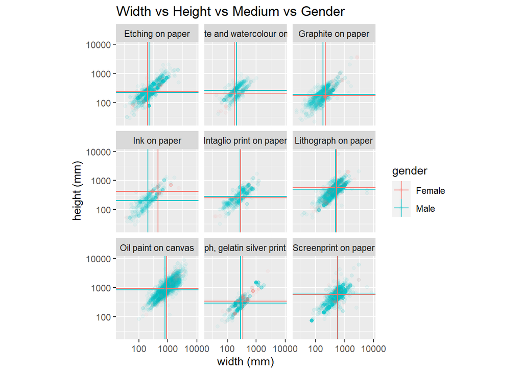

```r
top_9_mediums <- artist_work %>% group_by(medium) %>% count() %>% arrange(desc(n)) %>% head(9) %>% pull(1)

popular_mediums_art <- artist_work %>%
  filter(medium %in% top_9_mediums) %>%
  drop_na(width, height)

popular_mediums_art_gender <- artist_info %>%
  select(name, gender) %>%
  inner_join(popular_mediums_art, by = c("name" = "artist")) %>%
  group_by(medium, gender) %>%
  mutate(med_width = median(width),
         med_height = median(height),
         aspect_ratio = width / height) %>%
  filter(gender != "")

ggplot(popular_mediums_art_gender, aes(width, height, color = gender)) +
  geom_point(alpha = 0.05) +
  scale_x_log10() +
  scale_y_log10() +
  facet_wrap(~medium) +
  geom_hline(aes(yintercept = med_height, group = medium, color = gender)) +
  geom_vline(aes(xintercept = med_width, group = medium, color = gender)) +
  coord_fixed(ratio = 1) +
  ggtitle("Width vs Height vs Medium vs Gender") +
  xlab("width (mm)") +
  ylab("height (mm)")
```

I looked at the top nine popular mediums in the data set, which includes around 14k paintings. In this visualization, I facet using mediums and color according to gender. We can see that for both male and female artists, **Oil paint on canvas** has the biggest median width and height. It is 902x914 mm for women, and 787x828 mm for men. For males, **Graphite on paper** has the smallest median dimension: 183x191 mm, while for females, **Graphite and watercolour on paper** has the smallest median dimension: 174x207 mm.

```r
knitr::kable(popular_mediums_art_gender %>% distinct(med_width, med_height) %>% arrange(desc(med_width * med_height)))
```

| gender | medium | med_width | med_height |
| --- | --- | --- | --- |
| Female | Oil paint on canvas | 902.0 | 914.0 |
| Male | Oil paint on canvas | 787.0 | 828.0 |
| Male | Screenprint on paper | 588.0 | 597.0 |
| Female | Screenprint on paper | 555.0 | 571.0 |
| Female | Lithograph on paper | 530.0 | 571.0 |
| Male | Lithograph on paper | 476.0 | 492.0 |
| Female | Ink on paper | 459.0 | 419.0 |
| Female | Photograph, gelatin silver print on paper | 349.0 | 336.0 |
| Male | Photograph, gelatin silver print on paper | 290.0 | 292.0 |
| Male | Intaglio print on paper | 277.5 | 279.0 |
| Female | Intaglio print on paper | 284.0 | 254.0 |
| Male | Graphite and watercolour on paper | 211.0 | 257.0 |
| Male | Etching on paper | 225.0 | 218.0 |
| Female | Etching on paper | 200.0 | 233.5 |
| Male | Ink on paper | 203.0 | 205.5 |
| Female | Graphite on paper | 214.0 | 174.0 |
| Female | Graphite and watercolour on paper | 174.0 | 207.0 |
| Male | Graphite on paper | 183.0 | 191.0 |

For most mediums, the median width and height of artworks are pretty similar for male and female artists. The only exception is **Ink on paper**. For this category, both the median width and median height of females is more than double those of males.

## aspect ratio vs medium vs gender

In the previous visualization, I also observed that for all the mediums, there seem to be **two parallel diagonal lines**. This could mean that there are two popular aspect ratios of the artwork. I define the aspect ratio of an artwork to be width/height. This means if the aspect ratio is less than 1, the artwork is tall (portrait). Otherwise, the artwork is wide (landscape).

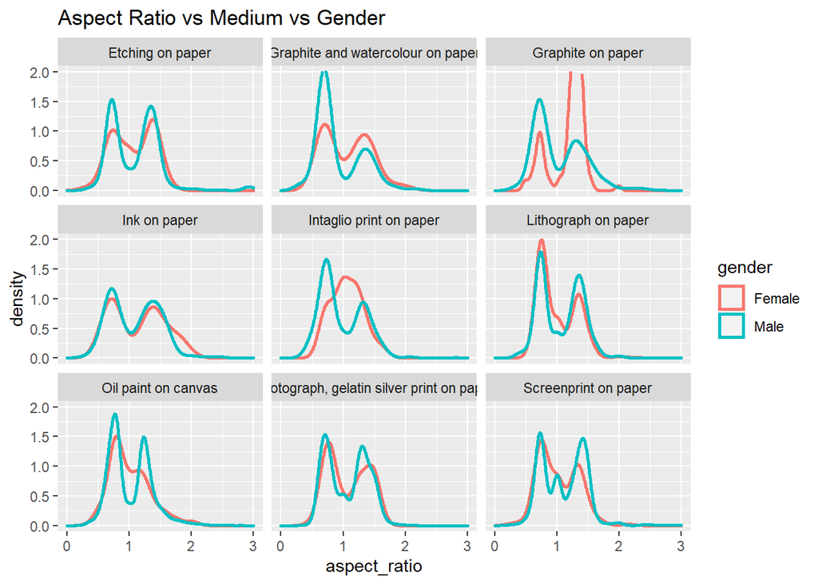

```r
ggplot(popular_mediums_art_gender, aes(aspect_ratio, color = gender)) +
  geom_density(size = 1) +
  facet_wrap(~medium) +
  xlim(c(0, 3)) +
  ylim(c(0, 2)) +
  ggtitle("Aspect Ratio vs Medium vs Gender")
```

As we can see in this visualization, almost all mediums display a **bimodal distribution** on aspect ratio. The two modes are around 0.6~0.8 and 1.2~1.5. This could be because most types of paper have a long side $\sqrt{2}$ times longer than the short side. Also, artists generally prefer tall artwork. Surprisingly, there are not a lot of square artworks. However, there are some exceptions in two categories. Let’s dig deeper.

### Intaglio print on paper, Female

```r
popular_mediums_art_gender %>% filter(aspect_ratio > 0.9, aspect_ratio < 1.11, gender == "Female", medium == "Intaglio print on paper") %>% group_by(name) %>% count() %>% arrange(desc(n))
```

```
## # A tibble: 4 x 2
## # Groups:   name [4]
##   name                 n
##   <chr>            <int>
## 1 Lim, Kim             6
## 2 Jansen, Angela       1
## 3 Skiöld, Birgit       1
## 4 Sydney, Berenice     1
```

I define an aspect ratio between 0.9 and 1.11 as a square artwork. Upon further inspection, **Lim, Kim** contributes to the spike of square artworks in the (Intaglio print on paper, Female) combination.

### Screenprint on paper, Male

```r
popular_mediums_art_gender %>% filter(aspect_ratio > 0.9, aspect_ratio < 1.11, gender == "Male", medium == "Screenprint on paper") %>% group_by(name) %>% count() %>% arrange(desc(n))
```

```
## # A tibble: 80 x 2
## # Groups:   name [80]
##    name                n
##    <chr>           <int>
##  1 Tyson, Ian         33
##  2 House, Gordon      30
##  3 Winner, Gerd       28
##  4 Denny, Robyn       22
##  5 Warhol, Andy       22
##  6 Pasmore, Victor    21
##  7 Cohen, Harold      16
##  8 Landsaat, Hans     16
##  9 Martin, Kenneth    12
## 10 Bayer, Herbert     11
## # ... with 70 more rows
```

In the (Screenprint on paper, Male) combination, there are 80 distinct artists who contributed to the spike of square artworks.

### Extra observations

In all the artwork using the Graphite on paper medium, male artists prefer tall artworks, while female artists prefer wide artworks.

```r
popular_mediums_art_gender %>% filter(aspect_ratio > 1.2, aspect_ratio < 1.4, gender == "Female", medium == "Graphite on paper") %>% group_by(name) %>% count() %>% arrange(desc(n))
```

```
## # A tibble: 5 x 2
## # Groups:   name [5]
##   name                   n
##   <chr>              <int>
## 1 Wharncliffe, Lady     40
## 2 Rigby, Elizabeth      14
## 3 Horn, Rebecca          3
## 4 Hambling, Maggi        1
## 5 Harrison, Margaret     1
```

**Wharncliffe, Lady** contributed 40 wide artworks in the (Graphite on paper, Female) combination, leading to the spike.